# Explanatory - Ford Go Bike's data - Feb 2019

### What is the structure of your dataset?

There are 183,412 trips in this dataset in Feb 2019 in San Francisco with information of each trip's starting station (station name, id, longtitude, latitude), end station (station name, id, longtitude, latitude), start time (date & hour), end time (date & hour), duration, who the rider was (their gender, age, user type), and which bike it was (shared bike or not, and bike id).

There are 329 stations in San Francisco, and a total of 4646 bikes.

### What is/are the main feature(s) of interest in your dataset?

1) I'm interested in investigating which stations are operating at their max capacity, and which stations are operating at a lost.

2) Besides that, I want to know which days and hours are the busiest and least busy, and some strategies to maximize the "dead hours" (least busy).

### What features in the dataset do you think will help support your investigation into your feature(s) of interest?

1) I think that other features like duration span and number of bikes are parked at each stations would be good indicators to determine which stations are operating at their fullest capacity or at a loss.

2) I think other demographic data such as member's birth year, gender, and user type can help me understand the peak days and hours better.

### Time

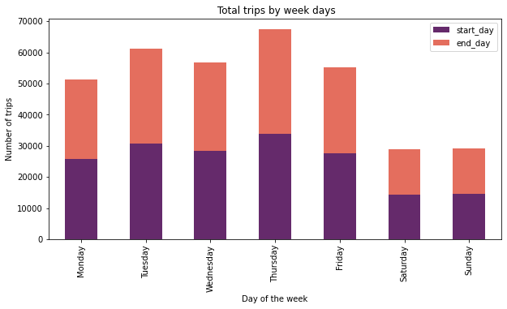

Thursdays have highest number of trips with a total of 67,461. Follwing by Tuesdays with 61,239 trips. On Mondays, Wednesdays and Fridays have somewhere from 51,000 to over 55,000 trips.

One of the reason this happens could be the majority of users only come to San Francisco during weekdays to work or use Ford bikes to commute to work. One thing Ford can do to boost the bikes usage during weekend is targeting tourists who usually spend weekends in San Francisco.

|  | start_day | end_day | total |
| --- | --- | --- | --- |
| Monday | 25686 | 25686 | 51372 |
| Tuesday | 30616 | 30623 | 61239 |
| Wednesday | 28456 | 28447 | 56903 |
| Thursday | 33733 | 33728 | 67461 |
| Friday | 27682 | 27674 | 55356 |
| Saturday | 14442 | 14450 | 28892 |
| Sunday | 14532 | 14539 | 29071 |

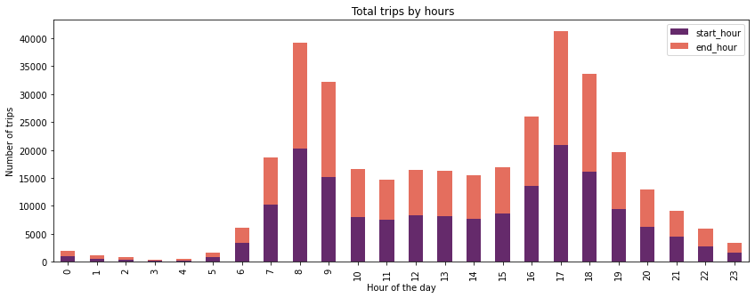

The most common start and end hours in the morning is from 8 to 9, and in the afternoon is from 17 to 18 also known as the rush hours. This again confirms the theory that most of the riders are professionals who use Ford bikes to commute to work.

|  | start_hour | end_hour |
| --- | --- | --- |
| 0 | 893 | 965 |
| 1 | 525 | 541 |
| 2 | 356 | 406 |
| 3 | 164 | 168 |
| 4 | 227 | 225 |
| 5 | 866 | 738 |
| 6 | 3294 | 2803 |
| 7 | 10235 | 8450 |
| 8 | 20242 | 19027 |
| 9 | 15221 | 16988 |
| 10 | 7980 | 8551 |
| 11 | 7473 | 7221 |
| 12 | 8237 | 8158 |
| 13 | 8118 | 8101 |
| 14 | 7694 | 7716 |
| 15 | 8657 | 8302 |
| 16 | 13492 | 12546 |
| 17 | 20921 | 20339 |
| 18 | 16133 | 17487 |
| 19 | 9432 | 10234 |
| 20 | 6220 | 6630 |
| 21 | 4401 | 4703 |
| 22 | 2793 | 3100 |
| 23 | 1573 | 1748 |

|  | 7 AM | 8 AM | 9 AM | 10 AM | 11 AM | 12 PM | 1 PM | 2 PM | 3 PM | 4 PM | 5 PM | 6 PM | 7 PM |
| --- | --- | --- | --- | --- | --- | --- | --- | --- | --- | --- | --- | --- | --- |
| Monday | 1653 | 3195 | 2231 | 1055 | 1044 | 1200 | 1044 | 915 | 1190 | 2006 | 3309 | 2366 | 1425 |
| Tuesday | 2185 | 4239 | 3239 | 1154 | 988 | 1094 | 1088 | 1081 | 1196 | 2190 | 3973 | 3150 | 1659 |
| Wednesday | 1803 | 3584 | 2576 | 1049 | 902 | 1066 | 958 | 952 | 1099 | 2128 | 3818 | 3054 | 1785 |
| Thursday | 2269 | 4475 | 2809 | 1283 | 1010 | 1247 | 1180 | 1133 | 1386 | 2595 | 4519 | 3624 | 1967 |
| Friday | 1958 | 3926 | 2991 | 1406 | 1284 | 1262 | 1083 | 909 | 1256 | 2090 | 3053 | 2217 | 1178 |
| Saturday | 205 | 497 | 781 | 1105 | 1167 | 1182 | 1361 | 1335 | 1204 | 1105 | 1079 | 792 | 662 |
| Sunday | 162 | 326 | 594 | 928 | 1078 | 1186 | 1404 | 1369 | 1326 | 1378 | 1170 | 930 | 756 |

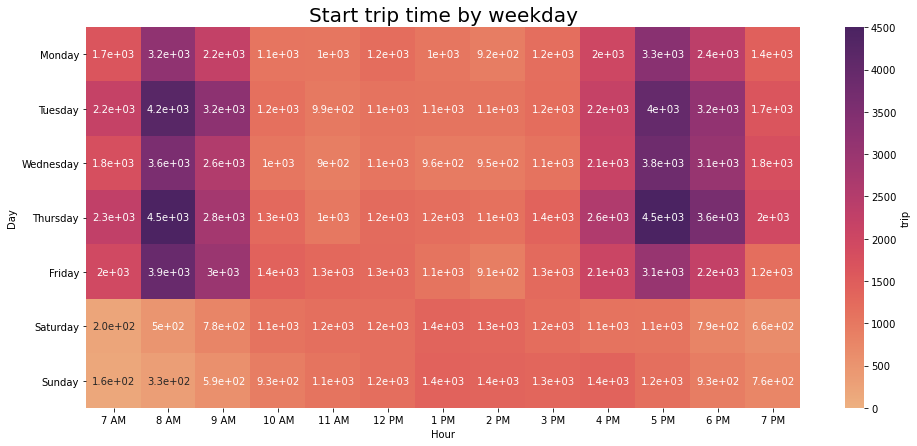

Most trip starts at 08 in the morning and again at 17 in the afternoon, following by trips start at 09 and 18. Tuesday and Thursday have the highest number of trips. Saturday and Sunday have the lowest number of trips.

|  | 7 AM | 8 AM | 9 AM | 10 AM | 11 AM | 12 PM | 1 PM | 2 PM | 3 PM | 4 PM | 5 PM | 6 PM | 7 PM |
| --- | --- | --- | --- | --- | --- | --- | --- | --- | --- | --- | --- | --- | --- |
| Monday | 1653 | 3195 | 2231 | 1055 | 1044 | 1200 | 1044 | 915 | 1190 | 2006 | 3309 | 2366 | 1425 |
| Tuesday | 2185 | 4239 | 3239 | 1154 | 988 | 1094 | 1088 | 1081 | 1196 | 2190 | 3973 | 3150 | 1659 |
| Wednesday | 1803 | 3584 | 2576 | 1049 | 902 | 1066 | 958 | 952 | 1099 | 2128 | 3818 | 3054 | 1785 |
| Thursday | 2269 | 4475 | 2809 | 1283 | 1010 | 1247 | 1180 | 1133 | 1386 | 2595 | 4519 | 3624 | 1967 |
| Friday | 1958 | 3926 | 2991 | 1406 | 1284 | 1262 | 1083 | 909 | 1256 | 2090 | 3053 | 2217 | 1178 |
| Saturday | 205 | 497 | 781 | 1105 | 1167 | 1182 | 1361 | 1335 | 1204 | 1105 | 1079 | 792 | 662 |
| Sunday | 162 | 326 | 594 | 928 | 1078 | 1186 | 1404 | 1369 | 1326 | 1378 | 1170 | 930 | 756 |

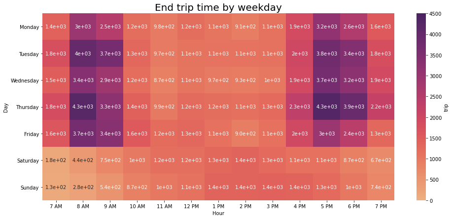

Most trip ends at 08 in the morning and again at 17 in the afternoon, following by trips start at 09 and 18. Tuesday and Thursday have the highest number of trips. Saturday and Sunday have the lowest number of trips.

|  | 7 AM | 8 AM | 9 AM | 10 AM | 11 AM | 12 PM | 1 PM | 2 PM | 3 PM | 4 PM | 5 PM | 6 PM | 7 PM |
| --- | --- | --- | --- | --- | --- | --- | --- | --- | --- | --- | --- | --- | --- |
| Monday | 1401 | 2994 | 2513 | 1190 | 975 | 1187 | 1067 | 906 | 1121 | 1883 | 3168 | 2597 | 1572 |
| Tuesday | 1794 | 4011 | 3659 | 1313 | 971 | 1084 | 1094 | 1099 | 1118 | 1989 | 3776 | 3441 | 1823 |
| Wednesday | 1484 | 3382 | 2906 | 1200 | 866 | 1065 | 974 | 933 | 1025 | 1913 | 3680 | 3247 | 1928 |
| Thursday | 1846 | 4261 | 3254 | 1419 | 989 | 1234 | 1186 | 1144 | 1262 | 2316 | 4321 | 3912 | 2193 |
| Friday | 1619 | 3661 | 3364 | 1565 | 1215 | 1314 | 1130 | 905 | 1133 | 1953 | 2993 | 2413 | 1310 |
| Saturday | 175 | 438 | 751 | 996 | 1172 | 1161 | 1285 | 1358 | 1253 | 1126 | 1139 | 866 | 668 |
| Sunday | 131 | 280 | 541 | 868 | 1033 | 1113 | 1365 | 1371 | 1390 | 1366 | 1262 | 1011 | 740 |

### Demography

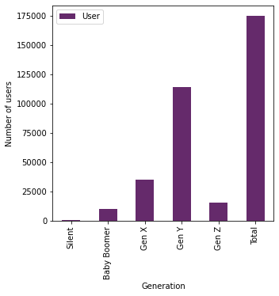

Ford may want to run more marketing campaigns targeting Bababy Boomers, Gen Z and Gen X to attract more users from this age group.

|  | User |
| --- | --- |
| Silent | 295 |
| Baby Boomer | 10254 |
| Gen X | 35062 |
| Gen Y | 113892 |
| Gen Z | 15569 |
| Total | 175072 |

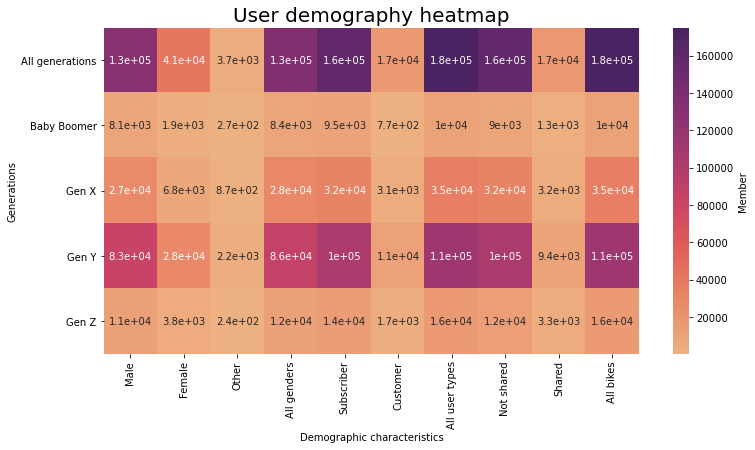

Gen Y Subscriber is the largest group in the heatmap with 102,911 users, 104,493 users in Gen Y don't share a bike and 83435 of them are males.

The third most popular group is Gen Z. One theory why Gen Z is not the popular users yet is that not many Gen Z are professionals who work in downtown San Francisco. However, Gen Z users may be blooming in couple years. One way to examinize this is to look at the growth of Gen Z users over the year.

| generation | Male | Female | Other | All genders | Subscriber | Customer | All user types | Not shared | Shared | All bikes |
| --- | --- | --- | --- | --- | --- | --- | --- | --- | --- | --- |
| All generations | 130591 | 40830 | 3651 | 134242 | 158446 | 16626 | 175072 | 157740 | 17332 | 175072 |
| Baby Boomer | 8090 | 1892 | 272 | 8362 | 9480 | 774 | 10254 | 8962 | 1292 | 10254 |
| Gen X | 27350 | 6843 | 869 | 28219 | 31930 | 3132 | 35062 | 31832 | 3230 | 35062 |
| Gen Y | 83435 | 28218 | 2239 | 85674 | 102911 | 10981 | 113892 | 104493 | 9399 | 113892 |
| Gen Z | 11483 | 3842 | 244 | 11727 | 13841 | 1728 | 15569 | 12273 | 3296 | 15569 |

### Location

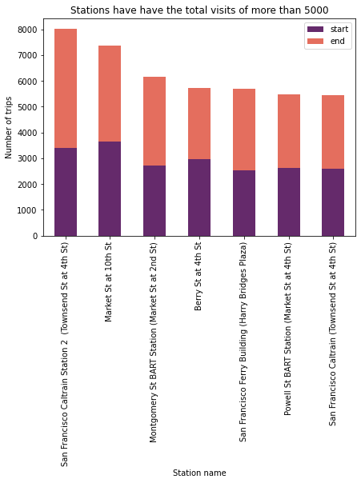

These are the 7 most profitable stations of Ford Go Bike with over 5000 visits.

Ford may want to collect more data on the wait time to get a bike at these top 7 most visited stations to see if there are longer wait times for users. If there're, Ford may want to add more bikes to these stations.

|  | start | end | total |
| --- | --- | --- | --- |
| San Francisco Caltrain Station 2 (Townsend St at 4th St) | 3408 | 4624 | 8032 |
| Market St at 10th St | 3649 | 3709 | 7358 |
| Montgomery St BART Station (Market St at 2nd St) | 2711 | 3461 | 6172 |
| Berry St at 4th St | 2952 | 2782 | 5734 |
| San Francisco Ferry Building (Harry Bridges Plaza) | 2541 | 3151 | 5692 |
| Powell St BART Station (Market St at 4th St) | 2620 | 2854 | 5474 |
| San Francisco Caltrain (Townsend St at 4th St) | 2577 | 2870 | 5447 |

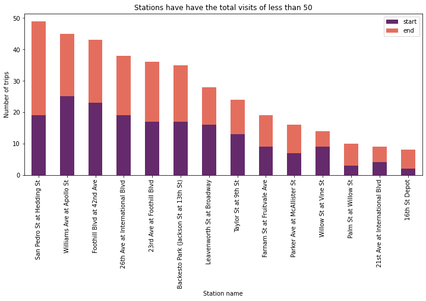

San Pedro St at Hedding St, Williams Ave at Apollo St and Foothill Blvd at 42nd Ave only have 49, 45 and 43 total visits respectively.

Ford may want to reconsider whether to continue operate the 14 stations above than have less than 50 visits a month like this. Considering the financially aspect, these stations are potentially operating at a loss. Second, considering customer service, not many customers would be swayed away if these 14 stations were to closed down. Lastly, considering the marketing aspect, these stations do not help with brand awareness or engagement as they surely do not attract enough users.

|  | start | end | total |
| --- | --- | --- | --- |
| San Pedro St at Hedding St | 19 | 30 | 49 |
| Williams Ave at Apollo St | 25 | 20 | 45 |
| Foothill Blvd at 42nd Ave | 23 | 20 | 43 |
| 26th Ave at International Blvd | 19 | 19 | 38 |
| 23rd Ave at Foothill Blvd | 17 | 19 | 36 |
| Backesto Park (Jackson St at 13th St) | 17 | 18 | 35 |
| Leavenworth St at Broadway | 16 | 12 | 28 |
| Taylor St at 9th St | 13 | 11 | 24 |
| Farnam St at Fruitvale Ave | 9 | 10 | 19 |
| Parker Ave at McAllister St | 7 | 9 | 16 |
| Willow St at Vine St | 9 | 5 | 14 |
| Palm St at Willow St | 3 | 7 | 10 |
| 21st Ave at International Blvd | 4 | 5 | 9 |
| 16th St Depot | 2 | 6 | 8 |

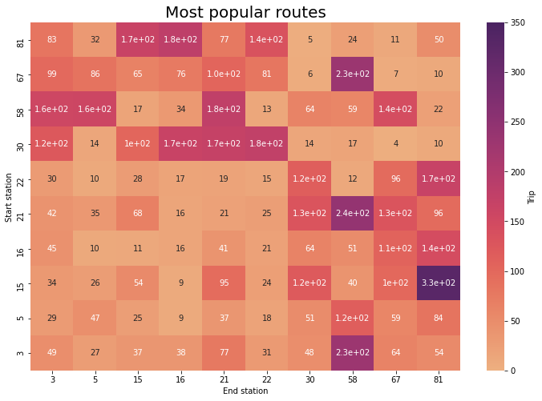

|  | 3 | 5 | 15 | 16 | 21 | 22 | 30 | 58 | 67 | 81 |
| --- | --- | --- | --- | --- | --- | --- | --- | --- | --- | --- |
| 81 | 83 | 32 | 166 | 181 | 77 | 135 | 5 | 24 | 11 | 50 |
| 67 | 99 | 86 | 65 | 76 | 105 | 81 | 6 | 232 | 7 | 10 |
| 58 | 157 | 158 | 17 | 34 | 178 | 13 | 64 | 59 | 143 | 22 |
| 30 | 124 | 14 | 103 | 166 | 170 | 175 | 14 | 17 | 4 | 10 |
| 22 | 30 | 10 | 28 | 17 | 19 | 15 | 115 | 12 | 96 | 168 |
| 21 | 42 | 35 | 68 | 16 | 21 | 25 | 131 | 243 | 130 | 96 |
| 16 | 45 | 10 | 11 | 16 | 41 | 21 | 64 | 51 | 108 | 144 |
| 15 | 34 | 26 | 54 | 9 | 95 | 24 | 121 | 40 | 100 | 327 |
| 5 | 29 | 47 | 25 | 9 | 37 | 18 | 51 | 116 | 59 | 84 |
| 3 | 49 | 27 | 37 | 38 | 77 | 31 | 48 | 230 | 64 | 54 |

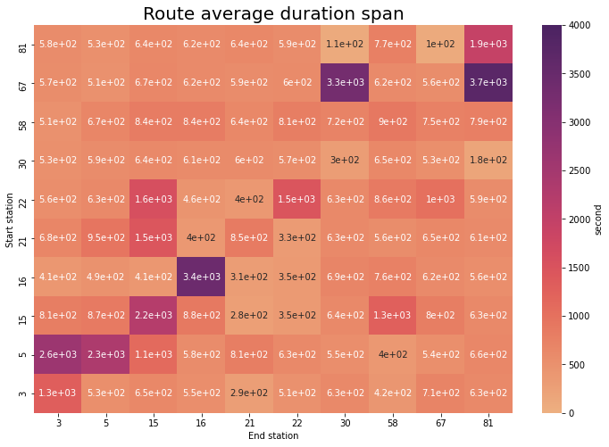

Interestingly, come second is a round trip starts and ends at the same station 16, Steuart St at Market St, with the average time span of 3426 seconds.

|  | 3 | 5 | 15 | 16 | 21 | 22 | 30 | 58 | 67 | 81 |
| --- | --- | --- | --- | --- | --- | --- | --- | --- | --- | --- |
| 81 | 578.518072 | 530.156250 | 644.162651 | 621.972376 | 640.714286 | 591.214815 | 109.000000 | 767.833333 | 100.181818 | 1940.720000 |
| 67 | 568.757576 | 513.953488 | 668.723077 | 621.684211 | 591.209524 | 598.790123 | 3298.833333 | 621.827586 | 563.571429 | 3721.700000 |
| 58 | 510.974522 | 674.373418 | 836.176471 | 842.794118 | 643.904494 | 805.230769 | 719.500000 | 903.067797 | 752.000000 | 786.818182 |
| 30 | 527.903226 | 588.785714 | 636.902913 | 608.024096 | 603.347059 | 565.377143 | 300.571429 | 648.117647 | 533.500000 | 181.700000 |
| 22 | 558.733333 | 627.000000 | 1604.000000 | 458.529412 | 402.894737 | 1482.466667 | 631.260870 | 859.666667 | 1021.770833 | 590.101190 |
| 21 | 677.404762 | 948.628571 | 1454.382353 | 402.562500 | 852.571429 | 332.080000 | 634.923664 | 563.477366 | 646.638462 | 611.656250 |
| 16 | 412.311111 | 487.400000 | 410.272727 | 3426.000000 | 306.439024 | 351.761905 | 694.578125 | 757.000000 | 618.120370 | 556.083333 |
| 15 | 807.147059 | 870.692308 | 2209.333333 | 878.333333 | 278.242105 | 345.791667 | 640.429752 | 1279.125000 | 799.610000 | 633.993884 |
| 5 | 2631.620690 | 2346.765957 | 1120.480000 | 584.555556 | 810.270270 | 629.111111 | 552.000000 | 400.543103 | 543.830508 | 662.071429 |
| 3 | 1324.938776 | 531.481481 | 648.081081 | 554.421053 | 291.693878 | 512.548387 | 631.312500 | 423.721739 | 708.937500 | 632.000000 |

## Further possible investigations

Although in this project, I chose to break down the data set into three areas - demography, time and location - to explore, there are interesting paths you can go when investigating this data.

One path would be looking across three areas I investigated above. Here are some ideas:

1) Find the peak times of the most popular stations.

2) Look at which user type uses the Ford Go Bike service more each day. Maybe there are more customers riding the bikes in the weekend.

3) Look at which stations have the highest Baby Boomers or Gen Z, and make suggestions if Ford should run some local marketing campaigns there.